# Cultural effects on German PISA 2012 scores

## by Markus Stachl

31.07.2021

## Investigation Overview

> PISA is the OECD's Programme for International Student Assessment. PISA measures 15-year-olds’ ability to use their reading, mathematics and science knowledge and skills to meet real-life challenges. I restricted the dataset to reponses from German students.

> The main goal is to analyse how the cultural and educational backgroud of students influence their school performance indicated by the PISA test results. I also want to highlight possible struggles of immigrants in Germany.

## How did German students do on PISA 2012?

> German students on average obtained higher results compared to the OECD average. This is the case for all three test subjects.

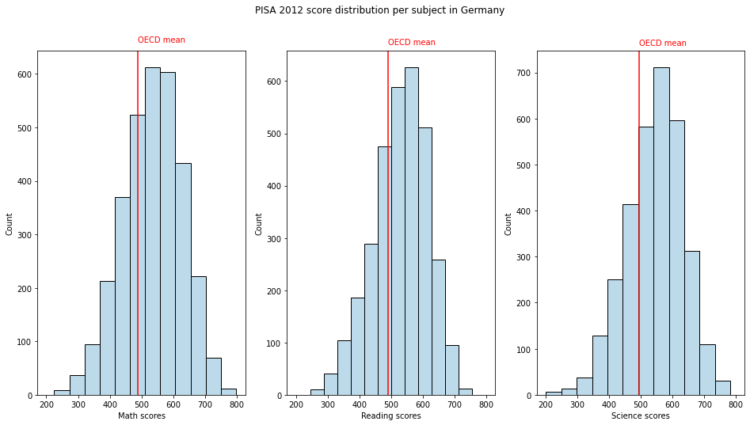

```python
math_oecd_mean = 488.3477719121511
reading_oecd_mean = 490.7844131820888
science_oecd_mean = 494.87909850752834
fig, axes = plt.subplots(1, 3, figsize=(16, 8), sharex=True)

sb.histplot(df_ger['math_score'], ax=axes[0], bins=12)
sb.histplot(df_ger['reading_score'], ax=axes[1], bins=12)
sb.histplot(df_ger['science_score'], ax=axes[2], bins=12)
axes[0].axvline(x=math_oecd_mean, color="red")
axes[0].text(math_oecd_mean,660,'OECD mean', color="red")
axes[1].axvline(x=reading_oecd_mean, color="red")
axes[1].text(reading_oecd_mean,670,'OECD mean', color="red")
axes[2].axvline(x=science_oecd_mean, color="red")
axes[2].text(science_oecd_mean,760,'OECD mean', color="red")

"""Set xlabels to destinguish plot target (math, reading, science)"""
axes[0].set_xlabel("Math scores")
axes[1].set_xlabel("Reading scores")
axes[2].set_xlabel("Science scores")
plt.suptitle('PISA 2012 score distribution per subject in Germany')
```

## Education stays in the family

> A strong indicator of student PISA scores is their parents education. If at least one parent has some level of higher education, their kids tend to perform better on PISA tests. This might be due to the fact that parents with higher education typically want their kids to follow in their footsteps and give their kids the needed support.

> Students, whos parents have not finished school, typically struggle in school as well.

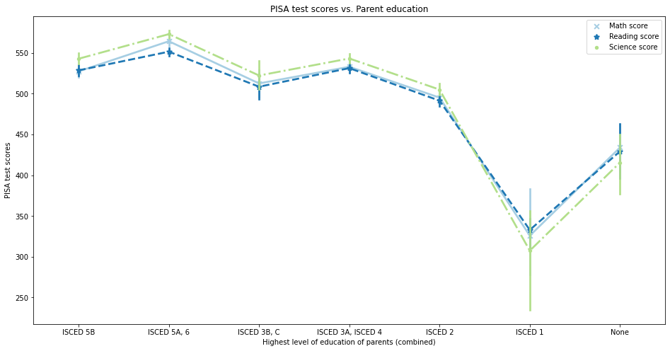

```python
plt.figure(figsize=(16,8))

df_scores = df_ger.melt('education_parents', value_vars=['math_score','reading_score','science_score'],
               var_name="score_type", value_name='score_value')
point = sb.pointplot(y="score_value", x="education_parents", order=education_categories.categories, data=df_scores, markers=["x","*","."], linestyles=["-", "--", "-."],  hue="score_type")
plt.title("PISA test scores vs. Parent education")
plt.xlabel("Highest level of education of parents (combined)")
plt.ylabel("PISA test scores")
new_labels = ["Math score", "Reading score", "Science score"]
for t, l in zip(point.legend().texts, new_labels): t.set_text(l)
```

## First generation immigrants struggle, but there is hope

> Around 10% of German students attending the survey are at least Second-generation immigrants

> Immigrants on average scored about 10% less in every PISA 2012 test subject.

> Second-generation immigrants can tighten the gap towards native students, suggesting that they can eliminate the initial handicap with the time being in Germany.

> Surprisingly, reading does not seem to be a bigger obstacle than mathematics or science.

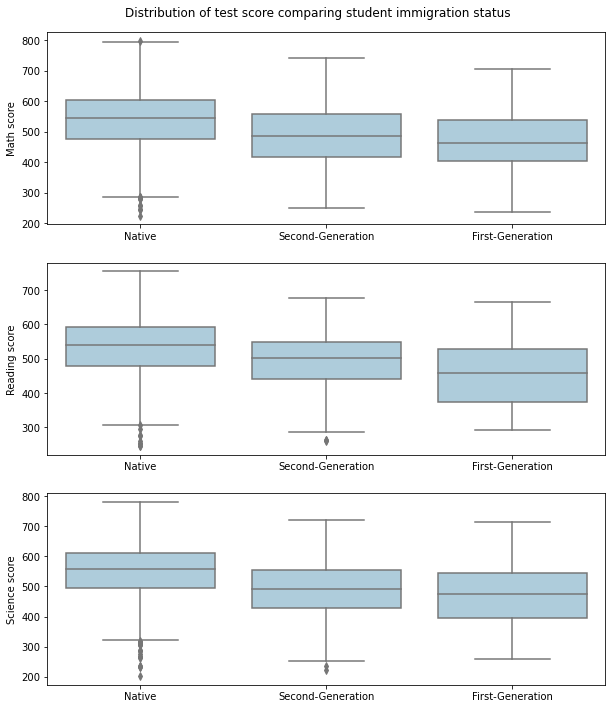

```python
fix, axes = plt.subplots(3,1,figsize=(10,12))
sb.boxplot(x="immigration_status", y="math_score", data=df_ger, ax=axes[0], color=color)
sb.boxplot(x="immigration_status", y="reading_score", data=df_ger, ax=axes[1], color=color)
sb.boxplot(x="immigration_status", y="science_score", data=df_ger, ax=axes[2], color=color)

"""Set y to destinguish plot target (math, reading, science)"""
axes[0].set_ylabel("Math score")
axes[1].set_ylabel("Reading score")
axes[2].set_ylabel("Science score")
axes[0].set_xlabel("")
axes[1].set_xlabel("")
axes[2].set_xlabel("")

"""Set plot title"""
plt.suptitle('Distribution of test score comparing student immigration status',y=0.91)
```

> Students living with a single parent perform equally well in all tests as their classmates living with both parents. It seems that most of single parents can handle the additional pressure pretty well.

> Students living in non-tradional family structures (without parents, with grand-parents or similar) tend to struggle greatly in school. This might be due to a lack of an attachment figure.

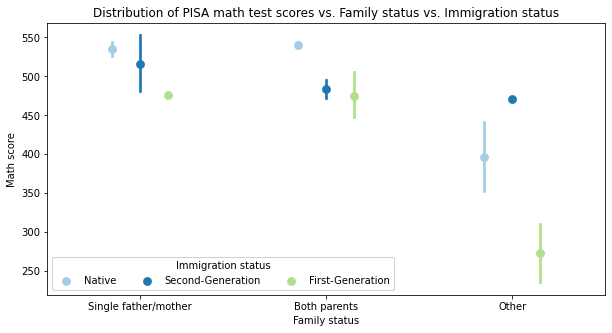

```python
plt.figure(figsize=(10,5))


ax = sb.pointplot(data = df_ger, x = 'family_structure', y = 'math_score', hue = 'immigration_status',
                  dodge = 0.3, linestyles = "")
ax.legend(loc = 0, ncol = 3, framealpha = .9, title = 'Immigration status')
ax.set_xlabel("Family status")
ax.set_ylabel("Math score")
plt.title("Distribution of PISA math test scores vs. Family status vs. Immigration status")
```